# R - Visualisierung

Dr. Katja Nieberle

2026-03-15

# Grafische Darstellung in R

## Linienplot plot() mit type=“l”

Zeigt Entwicklung über Zeit (z.B. Umsatz pro Monat).

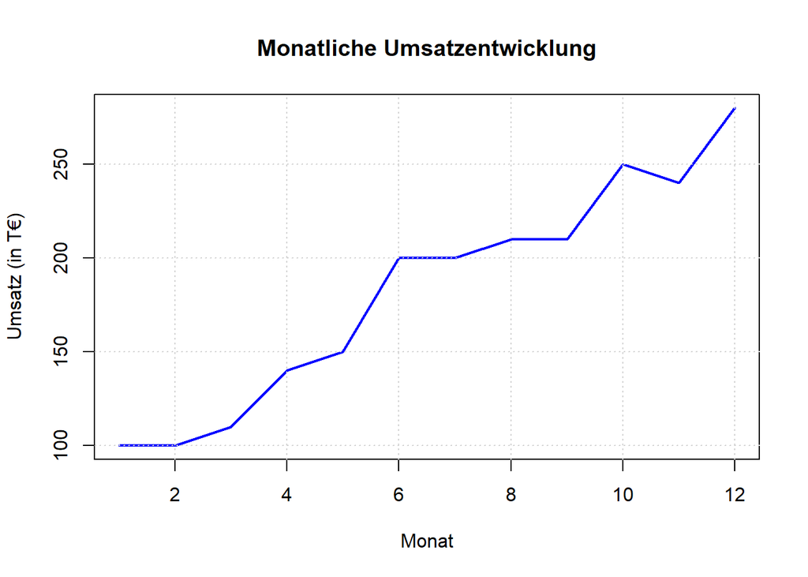

```r
# Beispiel-Daten
months <- 1:12
sales <- c(100, 100, 110, 140, 150, 200, 200, 210, 210, 250, 240, 280)

# Plot
plot(x=months, y=sales, type="l", lwd=2, col="blue",
     xlab="Monat", ylab="Umsatz (in T€)",
     main="Monatliche Umsatzentwicklung")
grid()
```

## Treppenfunktion

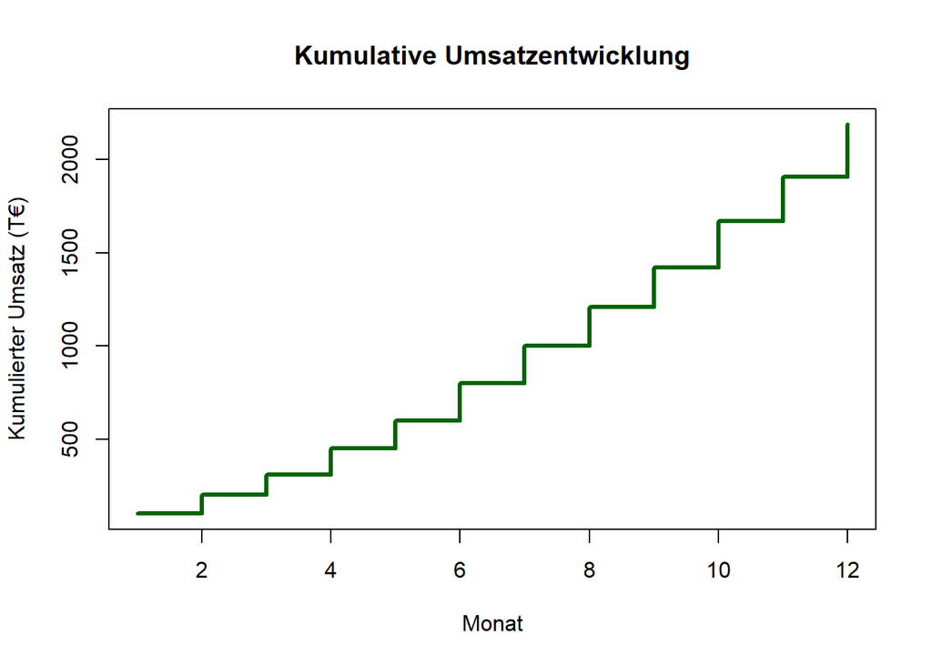

```r
# Kumulierter Umsatz
cum_sales <- cumsum(sales)
plot(months, cum_sales, type="s", lwd=3, col="darkgreen",
     xlab="Monat", ylab="Kumulierter Umsatz (T€)",
     main="Kumulative Umsatzentwicklung")
```

## Histogramm - hist()

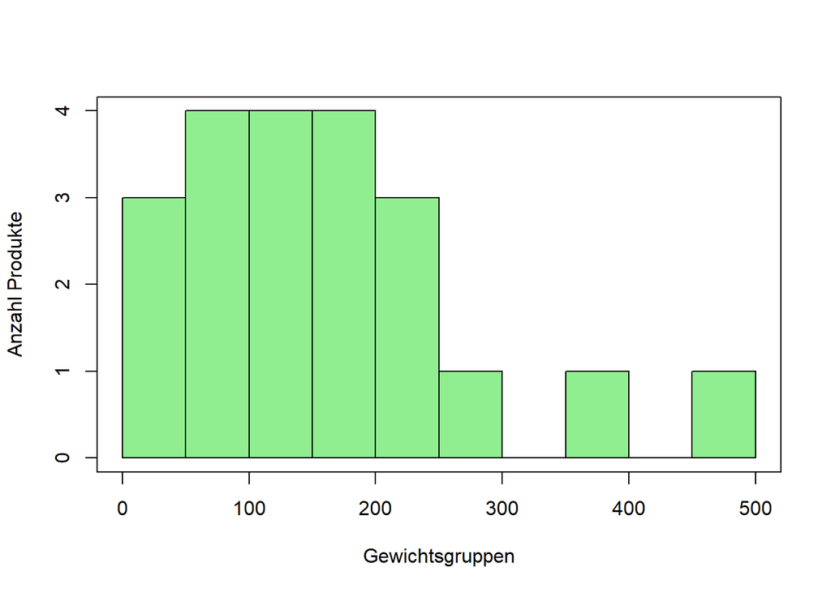

```r
choc_df <- data.frame(
  weight = c(100, 200, 360, 200, 100,
             50, 120, 40, 50, 55,
             90, 110, 130, 150, 170,
             190, 210, 230, 250, 300, 500),
  price  = c(2.99, 1.49, 5.99, 4.49, 1.19,
             1.79, 1.29, 0.79, 0.89, 0.99,
             1.59, 1.69, 1.89, 2.19, 2.39,
             2.59, 2.79, 2.99, 3.49, 3.99, 7.99),
  brand  = c("Lindt", "Milka", "Toblerone", "Ferrero Rocher", "Ritter Sport",
             "Lindt", "Milka", "KitKat", "Snickers", "Milky Way",
             "Lindt", "Milka", "Toblerone", "Ferrero Rocher", "Ritter Sport",
             "Lindt", "Milka", "KitKat", "Snickers", "Milky Way", "Milka")
)
hist(choc_df$weight, breaks=7, col="lightgreen",
     xlab="Gewichtsgruppen", ylab="Anzahl Produkte",
     main="",
     border="black")
box()
```

## Barplot

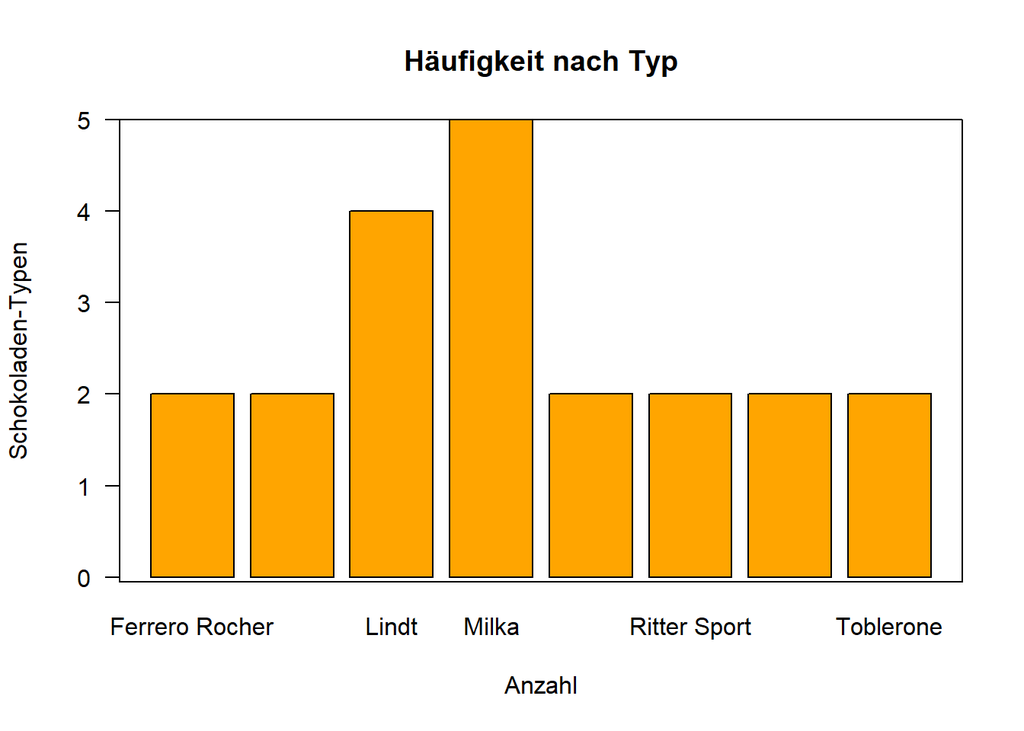

```r
brands <- table(choc_df$brand)
barplot(brands, horiz=FALSE, col="orange",
        xlab="Anzahl", ylab="Schokoladen-Typen",
        main="Häufigkeit nach Typ",
        las=1)  # Labels senkrecht
box()
```

## Boxplot

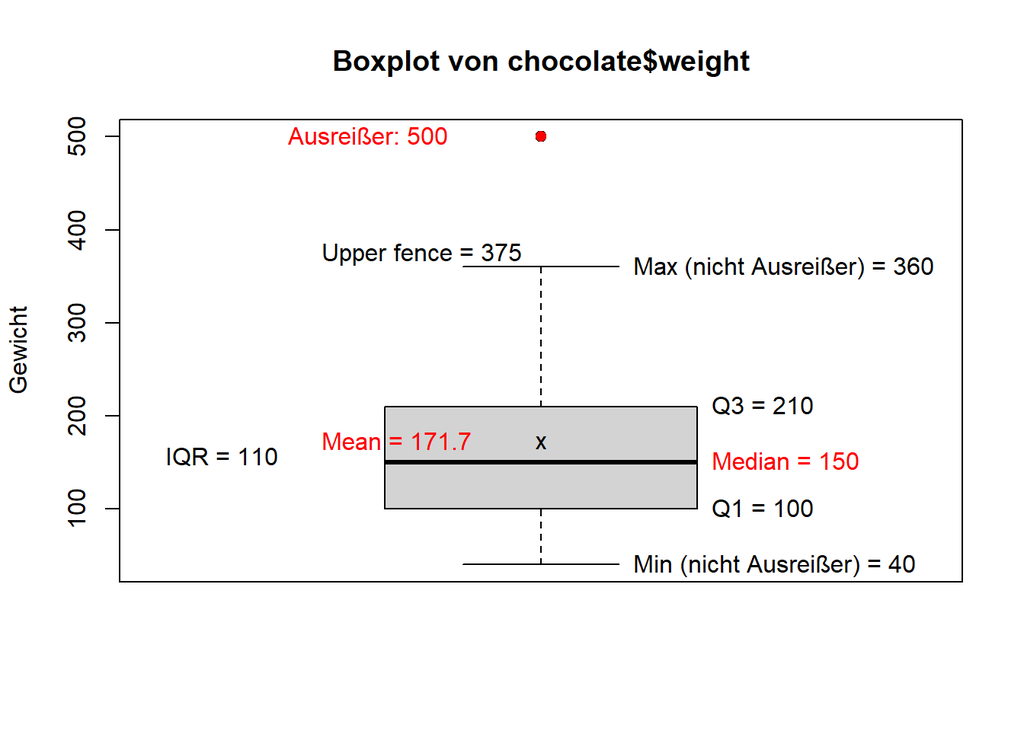

```r
# Basis-Boxplot
bp <- boxplot(choc_df$weight,
              main = "Boxplot von chocolate$weight",
              ylab = "Gewicht",
              col  = "lightgray")

# Statistiken aus boxplot.stats holen
bstats <- boxplot.stats(choc_df$weight)
stats  <- bstats$stats       # 5er-Statistik: min, Q1, median, Q3, max (ohne Ausreißer)
out    <- bstats$out         # Ausreißer
iqr    <- stats[4] - stats[2]

min_val <- stats[1]
q1      <- stats[2]
median  <- stats[3]
q3      <- stats[4]
max_val <- stats[5]
mean_val <- mean(choc_df$weight)

lower_fence <- q1 - 1.5 * iqr
upper_fence <- q3 + 1.5 * iqr

# Beschriftungen hinzufügen
text(x = 1, y = mean_val,labels ="x")
text(x = 0.7, y = mean_val,
     labels = paste0("Mean = ", round(mean_val, 1)),
     pos = 4, col = "red")

text(x = 1.2, y = median,
     labels = paste0("Median = ", round(median, 1)),
     pos = 4, col = "red")

text(x = 1.2, y = q1,
     labels = paste0("Q1 = ", round(q1, 1)),
     pos = 4, col = "black")

text(x = 1.2, y = q3,
     labels = paste0("Q3 = ", round(q3, 1)),
     pos = 4, col = "black")

text(x = 1.1, y = min_val,
     labels = paste0("Min (nicht Ausreißer) = ", round(min_val, 1)),
     pos = 4, col = "black")

text(x = 1.1, y = max_val,
     labels = paste0("Max (nicht Ausreißer) = ", round(max_val, 1)),
     pos = 4, col = "black")

text(x = 0.7, y = lower_fence,
     labels = paste0("Lower fence = ", round(lower_fence, 1)),
     pos = 4, col = "black")

text(x = 0.7, y = upper_fence,
     labels = paste0("Upper fence = ", round(upper_fence, 1)),
     pos = 4, col = "black")

text(x = 0.5, y = q1 + iqr/2,
     labels = paste0("IQR = ", round(iqr, 1)),
     pos = 4, col = "black")

# Ausreißer, falls vorhanden
if (length(out) > 0) {
  points(rep(1, length(out)), out, pch = 16, col = "red")
  text(x = 0.9, y = max(out),
       labels = paste("Ausreißer:", paste(round(out, 1), collapse = ", ")),
       pos = 2, col = "red")
}
```

## Scatterplot

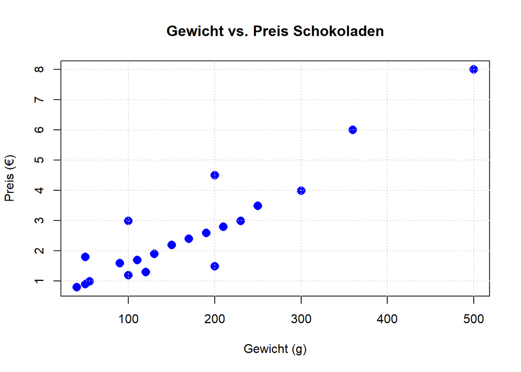

```r
plot(choc_df$weight, choc_df$price,
     pch=16, col="blue", cex=1.5,
     xlab="Gewicht (g)", ylab="Preis (€)",
     main="Gewicht vs. Preis Schokoladen")
grid()
```

## Kuchendiagramm - pie()

Anteile darstellen - ACHTUNG - verzerrte Wahrnehmung

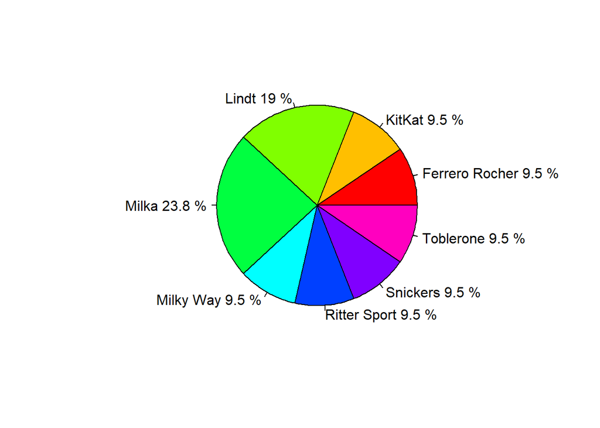

```r
# Marken zählen
pie(brands,
    col=rainbow(length(brands)),
    labels=paste(names(brands), round(100*brands/sum(brands), 1), "%"))
```

## Dichtefunktion

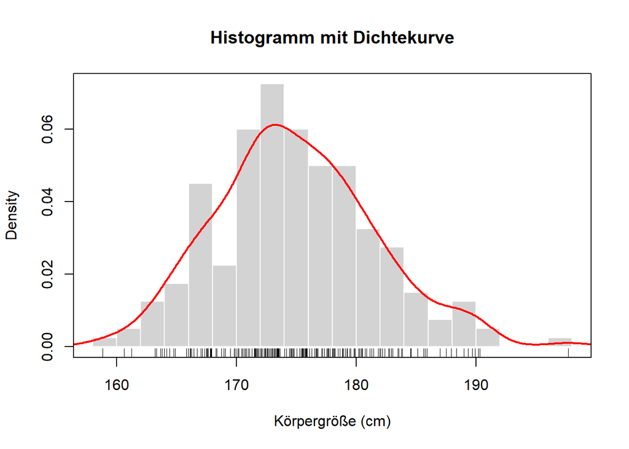

```r
set.seed(123)
bodysize <- rnorm(200, mean = 175, sd = 7)

bodysize_density <- density(bodysize)

hist(bodysize,
     breaks = 15,
     freq   = FALSE,
     main   = "Histogramm mit Dichtekurve",
     xlab   = "Körpergröße (cm)",
     col    = "lightgray",
     border = "white")

lines(bodysize_density, col = "red", lwd = 2)
rug(bodysize)  # kleine Striche für einzelne Beobachtungen auf der x-Achse
box()
```

## Korrelation Plot

```r
# Pakete
library(corrplot)
num_data <- subset(choc_df, select = c(weight, price))

# Korrelationsmatrix berechnen
cor_mat <- cor(num_data, use = "complete.obs", method = "pearson")
cor_mat
```

```
##           weight     price
## weight 1.0000000 0.9228908
## price  0.9228908 1.0000000
```

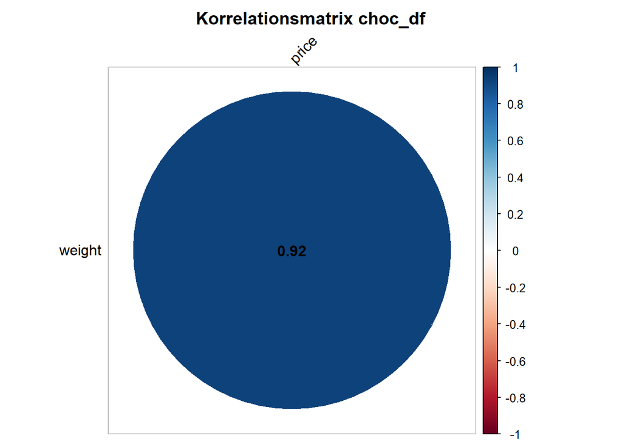

```r
# Einfache Visualisierung
corrplot(cor_mat,
         method = "circle",      # "circle", "square", "number" etc.
         type   = "upper",       # nur obere Dreiecksmatrix
         addCoef.col = "black",  # Korrelationswerte einblenden
         tl.col = "black",       # Textfarbe
         tl.srt = 45,            # Textrotation
         diag  = FALSE,
         title = "Korrelationsmatrix choc_df",
         mar   = c(0,0,2,0))
```

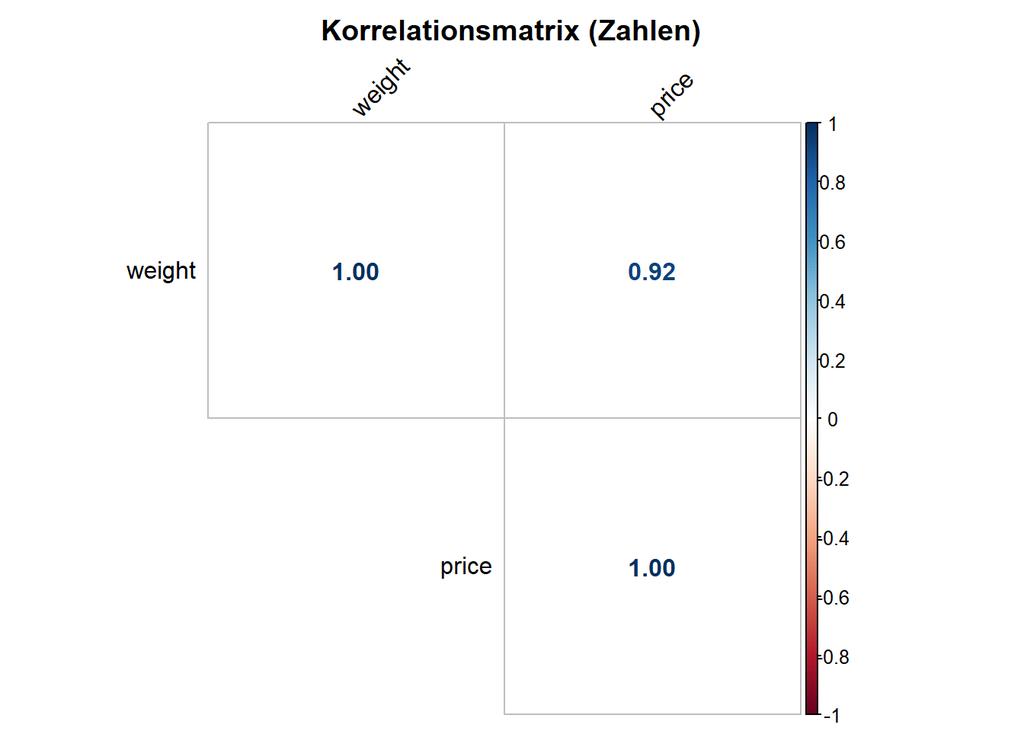

```r
# Alternative: nur Zahlen
corrplot(cor_mat,
         method = "number",
         type   = "upper",
         tl.col = "black",
         tl.srt = 45,
         title = "Korrelationsmatrix (Zahlen)",
         mar   = c(0,0,2,0))
```

## Speichern von Grafiken

**Vektorgrafik:**

Eine Vektorgrafik besteht aus Linien, Kurven, Textobjekten und Flächen, beschrieben durch mathematische Gleichungen (z.B. „Linie von (x1,y1) nach (x2,y2) in Blau“), nicht aus Pixeln.

**Vorteile von Vektorgrafiken:**

- Beliebig skalierbar ohne Qualitätsverlust; Achsenbeschriftungen und Linien bleiben gestochen scharf (wichtiger Punkt für Plots).
- Kleine Dateien bei vielen simplen Elementen (Linien, Punkte, Text).
- Ideal für Druck, PDFs, wissenschaftliche Artikel, LaTeX (pdf(), postscript()/eps() in R).

**Rastergrafiken (JPEG, PNG):**

Bestehen aus Pixeln; Beim starken Zoomen oder Drucken auf großem Format ergeben sich “Treppenartefakte”, unscharfe Schrift.

**Vorteile von Rastergrafiken:**

- Pixelgenau: Screenshot = Pixelgrafik von Natur aus
- Kopierbar: Rechtsklick –> “Bild speichern” –> fertig
- JPEG/PNG universell lesbar
- Benötigt keine Konvertierung

```r
# PDF in Hochformat: Höhe > Breite

# Passe deinen Pfad an!
pdf("boxplot_hoch.pdf", width = 7, height = 10)
boxplot(choc_df$weight,
        main = "Boxplot chocolate$weight (Hochformat)",
        ylab = "Gewicht")
dev.off()
```

```r
# JPEG in Querformat: Breite > Höhe

# Passe deinen Pfad an!
jpeg("scatter_quer.jpg",
     width = 1600, height = 900, units = "px", quality = 90)

plot(choc_df$weight, choc_df$price,
     main = "Gewicht vs. Preis (Querformat)",
     xlab = "Gewicht", ylab = "Preis",
     pch = 16, col = "blue")
dev.off()
```

```r
# EPS als klassisches Vektorformat für Journals/LaTeX

# Passe deinen Pfad an!
postscript("histogram_quer.eps",
           width = 10, height = 6, horizontal = FALSE,
           onefile = FALSE, paper = "special")

hist(choc_df$weight,
     main = "Histogramm chocolate$weight (EPS, Querformat)",
     xlab = "Gewicht", col = "lightgray", border = "white")
dev.off()
```

## Aufgaben

`pathname <- "data\\input\\oktoberfestgesamt19852024.csv"`

`read.csv2(pathname, sep=",")`

3. Erstelle 5 verschiedene Grafiken und speichere diese in einer pdf Datei im Verzeichis `R Projekt > graphics` ab.